# EC 523 Blog Post

Peter Suechting

11/22/2020

# Introduction: what relationship, if any?

What is the relationship between rates of warming in the contiguous United States since 1895 and recent presidential election results, from 2000 to 2016? One might question whether the rates of warming, as measured in increments of degrees Celsius per year, would really have much of an effect on which party voters choose in presidential elections. The saliency of climate change in the national political discourse has been rising over the past three decades, however, and it is probably fair to say that most American voters have some opinion on climate change, positive or negative. Moreover, the science attributing the increased extremity and occurrence of natural disasters has grown and become more certain. In addition, more and more people have become exposed to the impacts of warming on their lives and livelihoods, as recent extreme weather events like Hurricane Harvey, or the decimation of Paradise, CA have demonstrated in vivid detail. [“CarbonBrief”](https://www.carbonbrief.org/mapped-how-climate-change-affects-extreme-weather-around-the-world), for example, plots the incidence of extreme weather events and whether peer-reviewed studies have linked these events’ severity to climate change. Thus, it seems possible that a relationship between rates of warming and voting behavior may not only exist, but might strengthen over time as the cumulative amount of warming and associated impacts increases.

An assumption that the hypothesis above relies upon, it must be noted, is that voters tend to associate Democrats with climate action, and Republicans with climate denial (or a vaguer form of domestic fossil energy protectionism). My conclusions will be necessarily reliant upon this simplifying assumption, that voters pick Democrats for climate action and Republicans for climate denial/fossil energy protectionism. There is a further implicit assumption: voters experiencing warming interpret it as a case of climate change (whatever the valence of that interpretation is) and pick candidates based on what their desired outcomes regarding climate change are, whether that’s climate action or denial/fossil energy protectionism. With these caveats in mind, let’s turn to first to the data, and next to the testing of this hypothesized relationship between county-level rates of warming and Democratic vote share.

# Reproducing WaPo’s analysis:

## Calculating the average rate of warming at the county-level in the United States, from 1895 to 2019.

To analyze warming temperatures in the United States, I drew upon an analysis presented by The Washington Post.

- [“Extreme climate change has arrived in America,”](https://www.washingtonpost.com/graphics/2019/national/climate-environment/climate-change-america/) published August 13, 2019
- [“In fast-warming Minnesota, scientists are trying to plant the forests of the future,”](https://www.washingtonpost.com/graphics/2020/climate-solutions/climate-change-minnesota/) published April 29, 2020
- [“This giant climate hot spot is robbing the West of its water,”](https://www.washingtonpost.com/graphics/2020/national/climate-environment/climate-change-colorado-utah-hot-spot/) published August 7, 2020

The Washington Post used the National Oceanic and Atmospheric Administration’s Climate Divisional Database (nClimDiv) and Gridded 5km GHCN-Daily Temperature and Precipitation Dataset (nClimGrid) data sets, which provide monthly temperature data between 1895 and 2019 for the Lower 48 states. They calculate the annual mean temperature trends in each state and county in the Lower 48 using linear regression — analyzing both annual average temperatures and temperatures for the three-month winter season (December, January and February). The Washington Post offers several data files that reproduce their analysis of climate change:

1. [Processing nClimDiv data](https://washingtonpost.github.io/data-2C-beyond-the-limit-usa/analysis/process_nclimdiv.html)
2. [Modeling temperature change](https://washingtonpost.github.io/data-2C-beyond-the-limit-usa/analysis/model_temperature_change.html)
3. [Analyzing nClimGrid raster data](https://washingtonpost.github.io/data-2C-beyond-the-limit-usa/analysis/analyze_nclimgrid.html)

For the purposes of this post, I will only be using the first two files, to first process the data and then model rates of temperature change on the county level. Below, I echo some of the code, specifically the model temperature change, so readers can see how the key independent variable for this hypothesis testing exercise is constructed.

```r
# The function `modelAnnualTempChg` uses linear regression to model the relationship between the year and temperature. The slope of this model is an estimate of the rate at which the temperature is changing, which we then multiply by 124 to extrapolate the rate to an estimate of temperature change over the entire period from 1895 to 2019.

# this part is split out because we will reuse it later on.
extractModelVariables <-
  . %>%
  mutate(
    slope = mod$coefficients[2],
    intercept = mod$coefficients[1],
    pvalue=summary(mod)$coefficients[,4][2],
    rsquared=summary(mod)$r.squared,
    tempchg = slope * 124,
    centurychg = slope * 100,
    decadechg = slope * 10,
    tempchg_c = tempchg / 1.8,
    decadechg_c = decadechg / 1.8,
    bin = cut(tempchg_c, c(-Inf, 0, 0.5, 1.0, 1.5, 2, Inf))
  )

modelAnnualTempChg <-
  . %>%
  do(mod = lm(temp ~ year, data = .)) %>%
  extractModelVariables()
```

# Mapping County-Level Rates of Warming & Presidential Results

After loading and processing the data, the code for which I chose not to display due to its tediousness, I first map the data for the key independent variable, rate of warming in degrees Celsius, and the dependent variables, presidential election results, from 2000 to 2016.

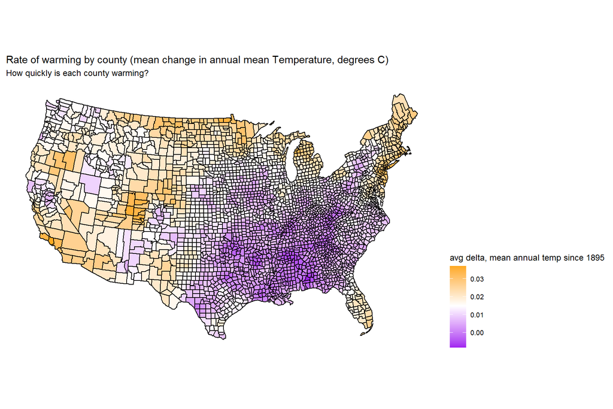

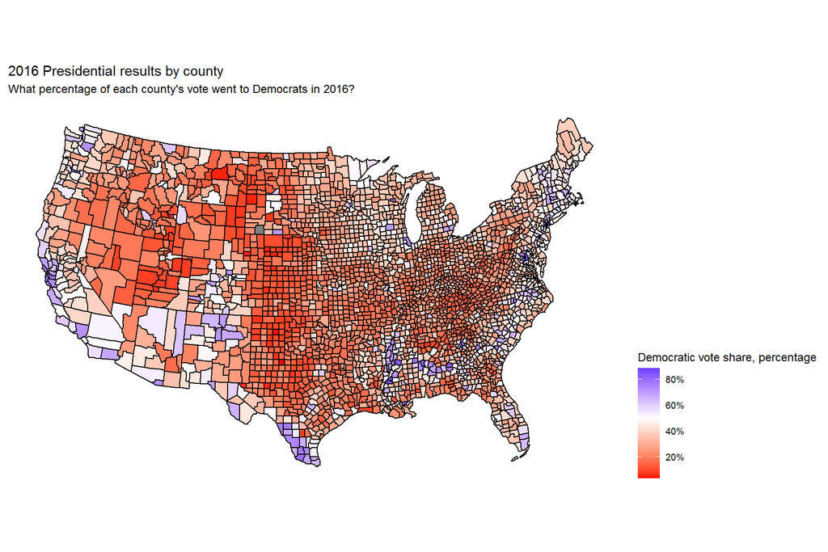

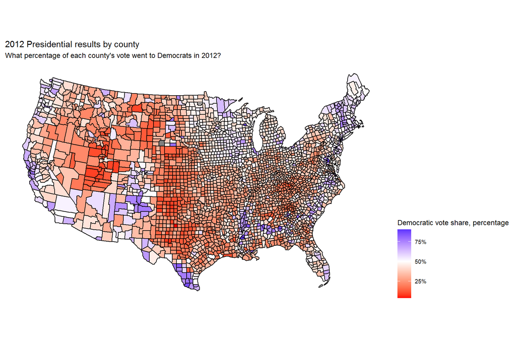

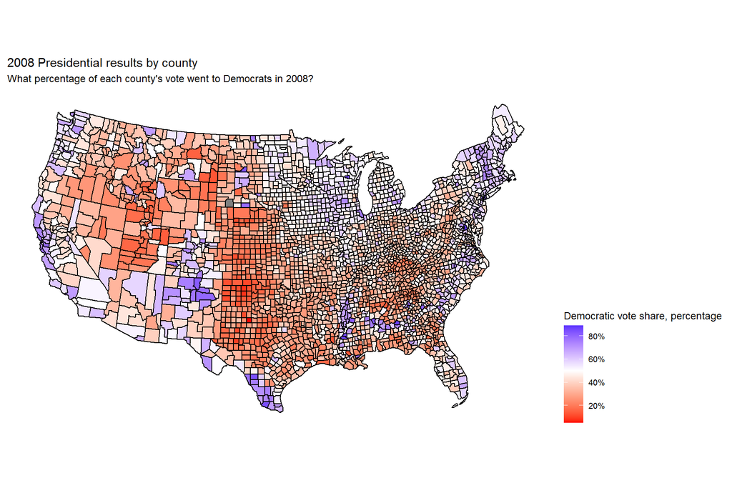

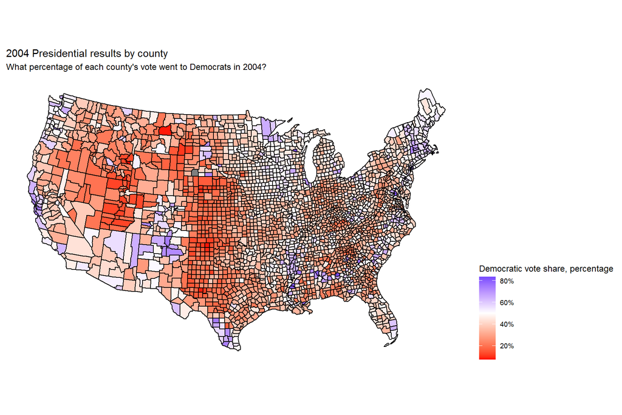

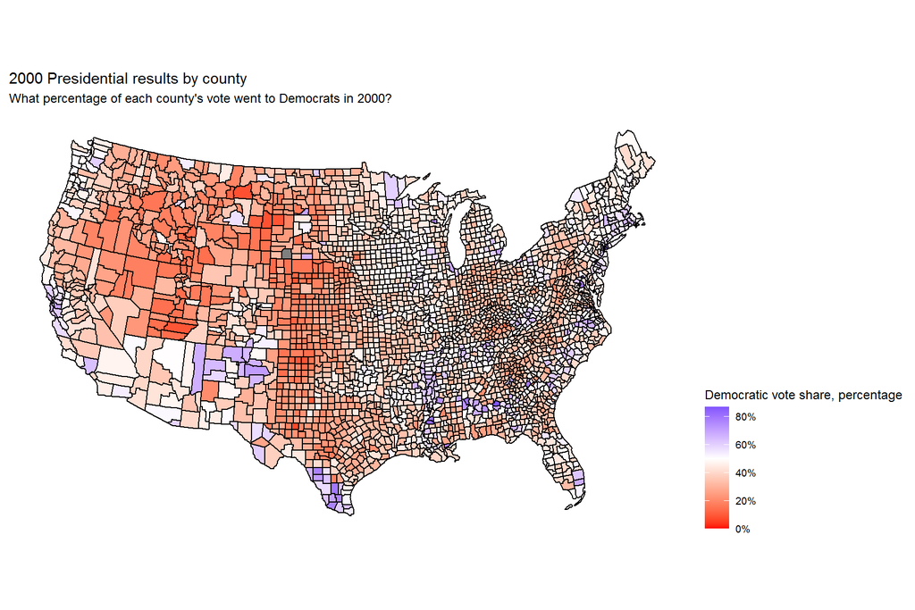

# Plotting County-level Presidential Results against Rates of Warming

Next, I plot the data for each county in each presidential election against the county’s rate of warming. Although a relationship between rate of warming and Democratic vote share is weak, and varies across election (which is to be expected), it is nonetheless present.

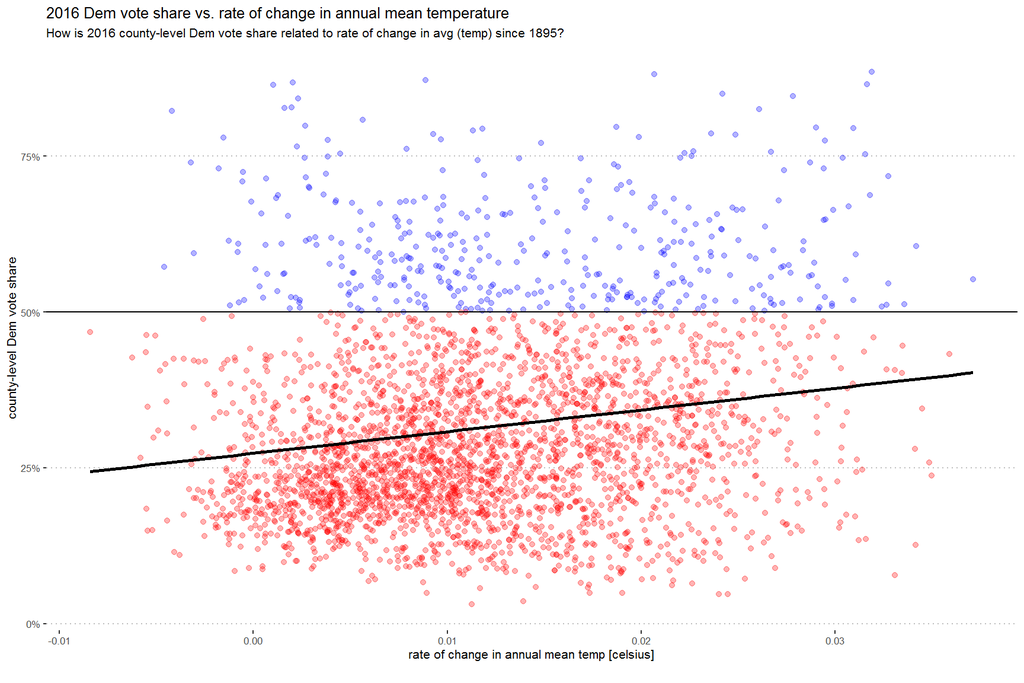

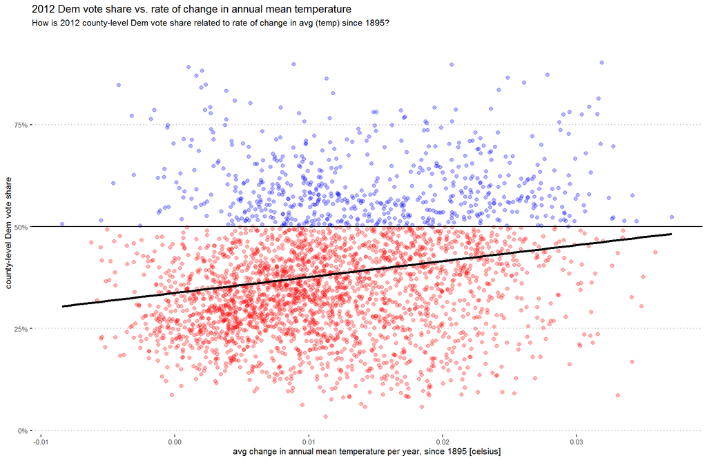

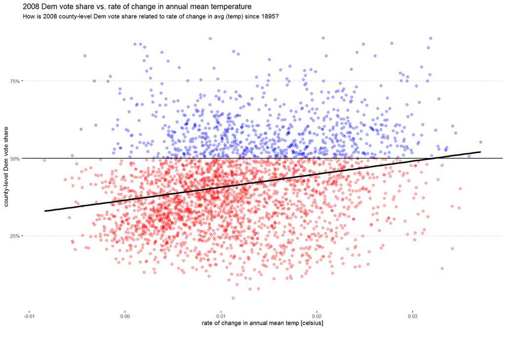

The relationship between county-level Democratic vote share and rate of warming is strongest in 2008, which may be interpreted as plausible evidence in support of the hypothesis. Barack Obama was a climate change candidate, famously remarking that his nomination to the Democratic candidacy would mark the moment ‘when the rise of the oceans began to slow and our planet began to heal’. The plot suggests, therefore, that it is at least possible that counties which experienced some amount of warming-related impacts interpreted them as harbingers of climate change and voted for the party of climate action. Again, however, I must stress that a causal relationship must not be inferred; only the strength and direction of association between the two variables is provided to us by the linear models fitted to the data.

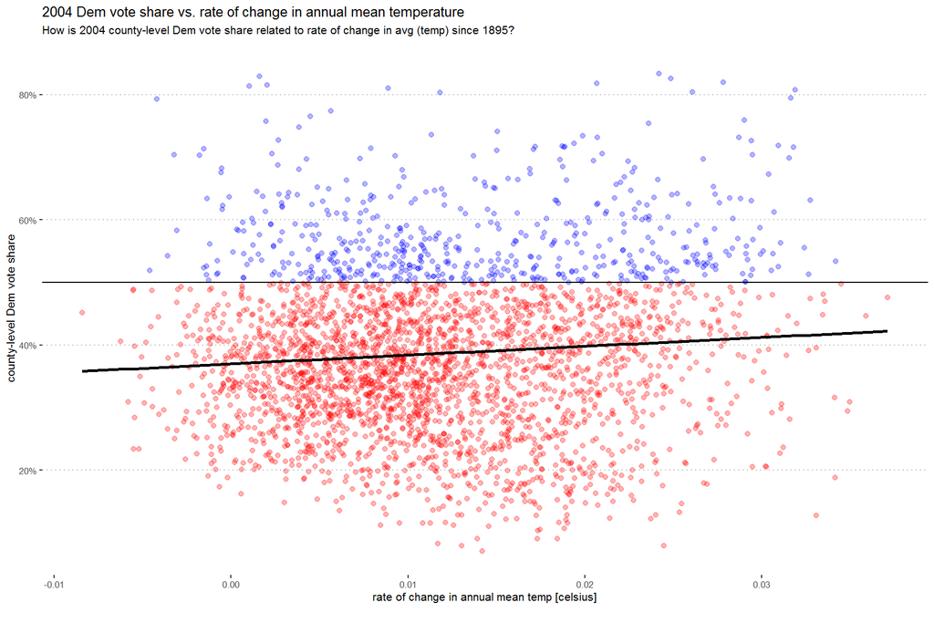

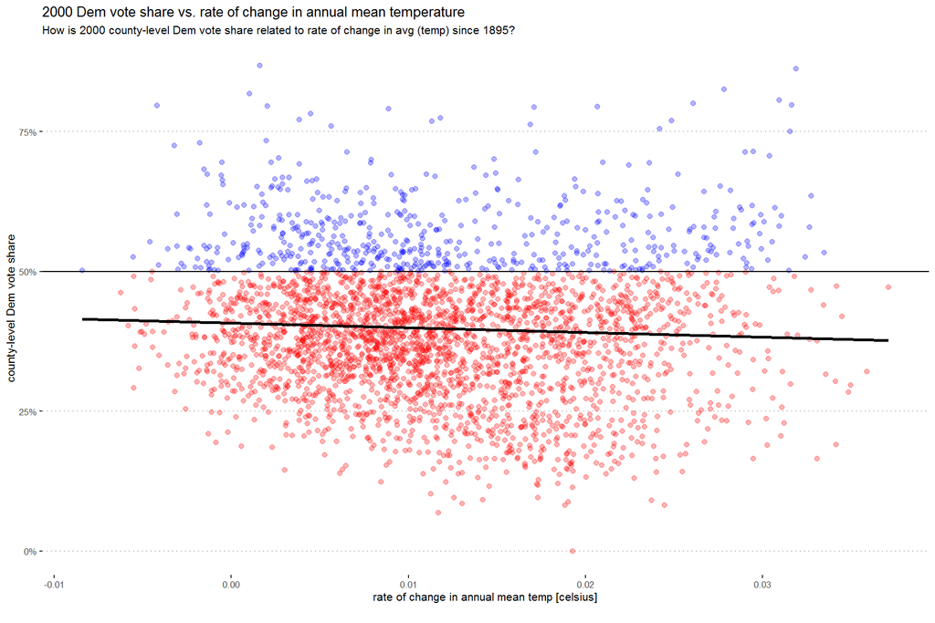

In the first elections analyzed here, in which Republicans prevailed in 2000 and 2004, the strength of the relationship between county-level rates of warming and Democratic vote share is weaker, and perhaps even negative. While it is possible to make up a narrative framing this as either positive or negative evidence for the hypothesized relationship, I prefer to view it as perhaps suggestive of temporal dynamism in the strength of the relationship over time. It could be one or both of the following: 1) either cumulative impacts had not developed enough for them to be interpretable as climate change-related; or, 2) that the Republican Party had not, at this point in history, wholly adopted a denier/fossil energy protectionist stance, and so the assumed identity between climate action and Democrats and Republicans with denial, respectively, may not have fully coalesced yet either. To put the latter reason in alternative language, the parties’ ideological stances regarding climate were poorly developed and so voters sorted themselves accordingly, which is to say poorly, between the two choices.

# Plotting County-Level Partisan Swing against Rates of Warming

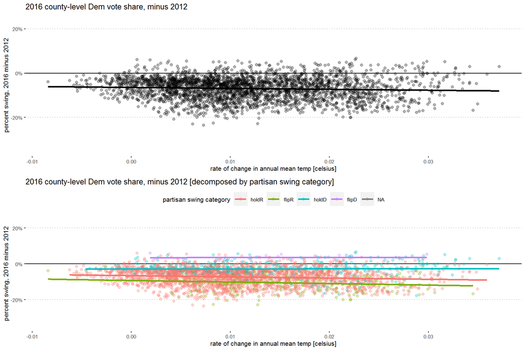

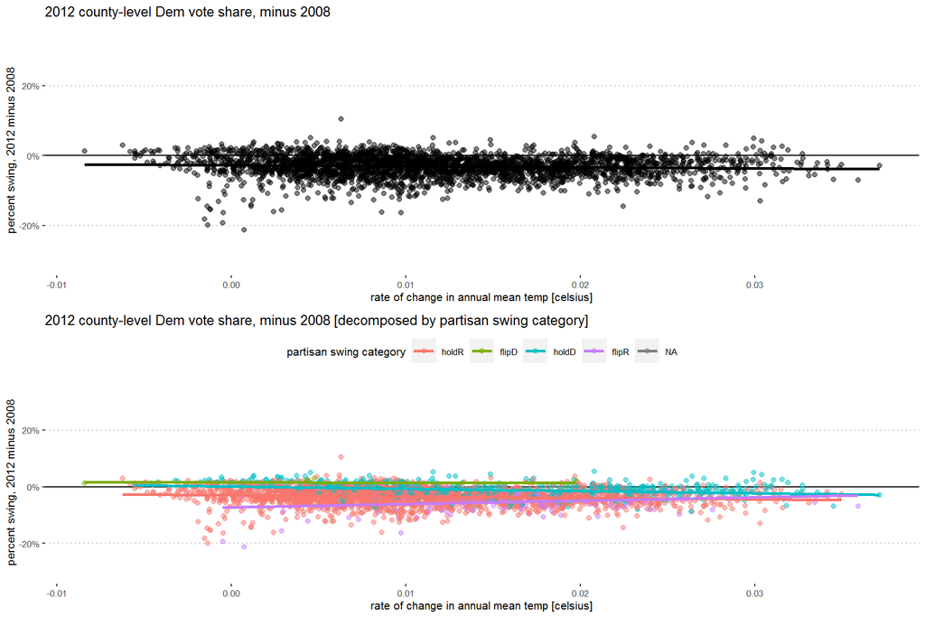

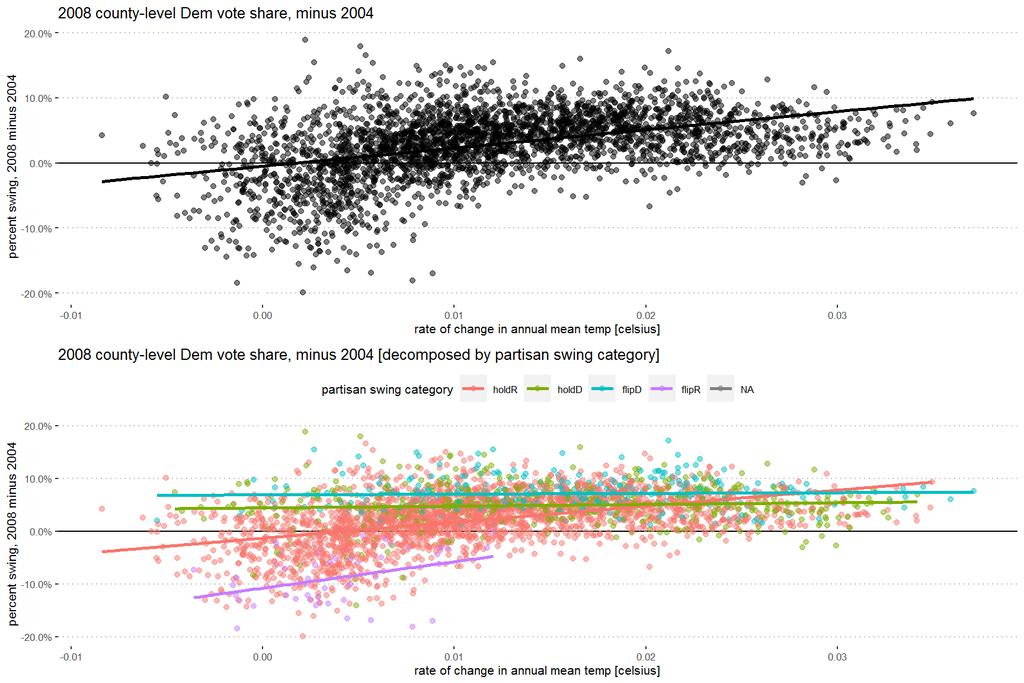

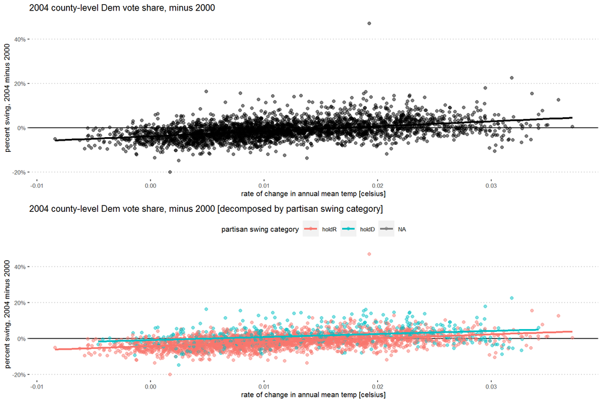

# Models: Presidential Results & Partisan Swing against Rate of Warming

model calls

|  | formula | data |
| --- | --- | --- |
| lm | dem2016 ~ slope | county_climpres |
| lm | dem12to16 ~ slope | county_climpres |
| lm | dem2012 ~ slope | county_climpres |
| lm | dem08to12 ~ slope | county_climpres |
| lm | dem2008 ~ slope | county_climpres |
| lm | dem04to08 ~ slope | county_climpres |
| lm | dem2004 ~ slope | county_climpres |
| lm | dem00to04 ~ slope | county_climpres |
| lm | dem2000 ~ slope | county_climpres |
| lm | dem00to16 ~ slope | county_climpres |
| lm | dem08to16 ~ slope | county_climpres |
| lm | dem04to12 ~ slope | county_climpres |
| lm | dem00to12 ~ slope | county_climpres |

The table above reports the model specifications for each model. The tables below report the results of these 13 different models. The first five models report the relationship between Democratic vote share on the county-level for the previous 5 elections, 2000, 2004, 2008, 2012, and 2016. The latter 8 models report the relationship between partisan swing in Democratic vote share by subtracting earlier results from later results for 8 different results-year-dyads: 2000 to 2004, 2000 to 2012, 2000 to 2016, 2004 to 2008, 2004 to 2012, 2008 to 2012, 2008 to 2016, and 2012 to 2016. Generally, the coefficients on the election results model are statistically significant, which means that we can reject the null hypothesis in all cases (no relationship between rate of warming and Democratic vote share). However, there is no possible way to generate a causal conclusion from these models; the treatment (rate of warming) is not randomly assigned (as the map at the beginning of this post indicates), with high rates of warming concentrated in the west and north/northeast, and lower rates of warming concentrated in the south of the country. What we can say, however, is that generally speaking, the models predict that frontline counties (higher rates of warming) are associated with a couple percentage points higher Democratic vote share than counties on the back-end of warming (lower rates of warming).

**linear models: political results against rate of change in mean annual temperature**

|  | dem2016 | dem2012 | dem2008 | dem2004 | dem2000 |
| --- | --- | --- | --- | --- | --- |
|  | (1) | (2) | (3) | (4) | (5) |
| rate of change [celsius] | 3.483*** | 3.906*** | 4.208*** | 1.408*** | -0.836*** |
|  | (0.337) | (0.324) | (0.302) | (0.280) | (0.266) |
| intercept | 0.273*** | 0.338*** | 0.365*** | 0.370*** | 0.408*** |
|  | (0.005) | (0.005) | (0.004) | (0.004) | (0.004) |
| *N* | 3,105 | 3,105 | 3,105 | 3,105 | 3,105 |
| R<sup>2</sup> | 0.033 | 0.045 | 0.059 | 0.008 | 0.003 |
| *Notes:* | ***Significant at the 1 percent level. |  |  |  |  |
|  | **Significant at the 5 percent level. |  |  |  |  |
|  | *Significant at the 10 percent level. |  |  |  |  |

**linear models: partisan swing against rate of change in mean annual temperature**

|  | dem12to16 | dem08to12 | dem04to08 | dem00to04 | dem00to16 | dem08to16 | dem04to12 | dem00to12 |
| --- | --- | --- | --- | --- | --- | --- | --- | --- |
|  | (1) | (2) | (3) | (4) | (5) | (6) | (7) | (8) |
| rate of change [celsius] | -0.423*** | -0.302*** | 2.800*** | 2.244*** | 4.319*** | -0.725*** | 2.498*** | 4.742*** |
|  | (0.110) | (0.068) | (0.103) | (0.086) | (0.209) | (0.141) | (0.123) | (0.163) |
| intercept | -0.064*** | -0.027*** | -0.005*** | -0.038*** | -0.134*** | -0.092*** | -0.032*** | -0.070*** |
|  | (0.002) | (0.001) | (0.001) | (0.001) | (0.003) | (0.002) | (0.002) | (0.002) |
| *N* | 3,105 | 3,105 | 3,105 | 3,105 | 3,105 | 3,105 | 3,105 | 3,105 |
| R<sup>2</sup> | 0.005 | 0.006 | 0.192 | 0.180 | 0.121 | 0.008 | 0.118 | 0.215 |
| *Notes:* | ***Significant at the 1 percent level. |  |  |  |  |  |  |  |
|  | **Significant at the 5 percent level. |  |  |  |  |  |  |  |
|  | *Significant at the 10 percent level. |  |  |  |  |  |  |  |

# Model Results: Presidential Results & Partisan Swing against Rate of Warming

Finally, I collect the results of each model – the coefficient and upper and lower confidence intervals – and plot them below to depict the range of possible means with which our population data is consistent. By and large, increase in the rate of warming is associated in the latter four elections (2004, 2008, 2012, and 2016) with increases in Democratic vote share, and the null hypothesis (no relationship) is effectively ruled out by the fact the confidence intervals on these coefficients does not include zero. For partisan swing, the results are more difficult to interpret. In essence, there is a non-zero relationship (null hypothesis ruled out) between rates of warming and partisan swing. Interestingly, the largest time interval for which we can calculate a partisan swing, from 2000 to 2016, reports the second highest coefficient on the relationship between warming and Democratic vote share. This model predicts about 4.32 more percentage points of Democratic vote share at the county level for each .01 degree Celsius increase in the rate of warming, which is fairly significant.

[figure not shown]

reported coefficients on modeled relationships and upper and lower bounds of 95% confidence intervals

[output not shown]

| State | Temperature change | Temperature change (Decade) | Rate of change |
| --- | --- | --- | --- |
| Rhode Island | 2.04ºC (3.67ºF) | 0.165ºC (0.296ºF) | 0.03 |
| New Jersey | 1.98ºC (3.56ºF) | 0.159ºC (0.287ºF) | 0.03 |
| Connecticut | 1.8ºC (3.24ºF) | 0.145ºC (0.261ºF) | 0.03 |
| Maine | 1.74ºC (3.14ºF) | 0.141ºC (0.253ºF) | 0.03 |
| Massachusetts | 1.7ºC (3.06ºF) | 0.137ºC (0.247ºF) | 0.02 |
| Delaware | 1.66ºC (2.99ºF) | 0.134ºC (0.241ºF) | 0.02 |
| North Dakota | 1.65ºC (2.98ºF) | 0.133ºC (0.24ºF) | 0.02 |
| New Hampshire | 1.62ºC (2.92ºF) | 0.131ºC (0.235ºF) | 0.02 |
| Utah | 1.58ºC (2.84ºF) | 0.127ºC (0.229ºF) | 0.02 |
| Michigan | 1.58ºC (2.84ºF) | 0.127ºC (0.229ºF) | 0.02 |
| Minnesota | 1.56ºC (2.8ºF) | 0.125ºC (0.226ºF) | 0.02 |
| Vermont | 1.55ºC (2.79ºF) | 0.125ºC (0.225ºF) | 0.02 |
| Wyoming | 1.51ºC (2.71ºF) | 0.121ºC (0.219ºF) | 0.02 |
| Oregon | 1.5ºC (2.7ºF) | 0.121ºC (0.218ºF) | 0.02 |
| California | 1.48ºC (2.67ºF) | 0.12ºC (0.215ºF) | 0.02 |
| Colorado | 1.44ºC (2.59ºF) | 0.116ºC (0.209ºF) | 0.02 |
| Montana | 1.42ºC (2.56ºF) | 0.115ºC (0.206ºF) | 0.02 |
| Maryland | 1.35ºC (2.43ºF) | 0.109ºC (0.196ºF) | 0.02 |
| Arizona | 1.32ºC (2.38ºF) | 0.106ºC (0.192ºF) | 0.02 |
| Nevada | 1.3ºC (2.34ºF) | 0.105ºC (0.189ºF) | 0.02 |
| South Dakota | 1.25ºC (2.25ºF) | 0.101ºC (0.181ºF) | 0.02 |
| New York | 1.2ºC (2.17ºF) | 0.0972ºC (0.175ºF) | 0.02 |
| New Mexico | 1.16ºC (2.09ºF) | 0.0935ºC (0.168ºF) | 0.02 |
| Wisconsin | 1.16ºC (2.09ºF) | 0.0935ºC (0.168ºF) | 0.02 |
| Idaho | 1.05ºC (1.88ºF) | 0.0844ºC (0.152ºF) | 0.02 |
| Washington | 1.04ºC (1.88ºF) | 0.084ºC (0.151ºF) | 0.02 |
| Florida | 1.03ºC (1.86ºF) | 0.0834ºC (0.15ºF) | 0.02 |
| Nebraska | 0.99ºC (1.78ºF) | 0.0798ºC (0.144ºF) | 0.01 |
| Pennsylvania | 0.967ºC (1.74ºF) | 0.078ºC (0.14ºF) | 0.01 |
| Kansas | 0.858ºC (1.54ºF) | 0.0692ºC (0.125ºF) | 0.01 |
| Ohio | 0.825ºC (1.49ºF) | 0.0666ºC (0.12ºF) | 0.01 |
| Illinois | 0.814ºC (1.47ºF) | 0.0657ºC (0.118ºF) | 0.01 |
| Virginia | 0.781ºC (1.41ºF) | 0.063ºC (0.113ºF) | 0.01 |
| Texas | 0.754ºC (1.36ºF) | 0.0608ºC (0.109ºF) | 0.01 |
| Indiana | 0.713ºC (1.28ºF) | 0.0575ºC (0.104ºF) | 0.01 |
| Iowa | 0.647ºC (1.17ºF) | 0.0522ºC (0.094ºF) | 0.01 |
| North Carolina | 0.624ºC (1.12ºF) | 0.0503ºC (0.0906ºF) | 0.01 |
| South Carolina | 0.546ºC (0.983ºF) | 0.044ºC (0.0793ºF) | 0.01 |
| West Virginia | 0.497ºC (0.895ºF) | 0.0401ºC (0.0722ºF) | 0.01 |
| Missouri | 0.491ºC (0.884ºF) | 0.0396ºC (0.0713ºF) | 0.01 |
| Georgia | 0.383ºC (0.69ºF) | 0.0309ºC (0.0557ºF) | 0.01 |
| Oklahoma | 0.36ºC (0.647ºF) | 0.029ºC (0.0522ºF) | 0.01 |
| Kentucky | 0.319ºC (0.574ºF) | 0.0257ºC (0.0463ºF) | 0.00 |
| Tennessee | 0.243ºC (0.438ºF) | 0.0196ºC (0.0353ºF) | 0.00 |
| Louisiana | 0.243ºC (0.437ºF) | 0.0196ºC (0.0353ºF) | 0.00 |
| Arkansas | 0.214ºC (0.385ºF) | 0.0172ºC (0.031ºF) | 0.00 |
| Mississippi | 0.0137ºC (0.0246ºF) | 0.0011ºC (0.00199ºF) | 0.00 |
| Alabama | -0.0353ºC (-0.0635ºF) | -0.00284ºC (-0.00512ºF) | 0.00 |

# Concluding thoughts

There is some suggestive and some more ambiguous evidence here of the presence of a relationship at the county level between partisan selection during elections and the rate of warming experienced, but we cannot conclude anything regarding causality. Further research should examine, separately and in conjunction with rates of warming, rates of change in precipitation, and whether there is any singular and/or joint variation (with warming rates) with presidential results and partisan swing.